# Tutorial: Modelos de RegressãO Linear

Washington Santos da Silva

# Regressão Linear Simples em R

## Aplicação: Razão Ótima de Hedge - Brooks (2019).

Embora existam muitas técnicas disponíveis para reduzir e gerenciar riscos, a mais simples e talvez a mais utilizada é o hedge com contratos futuros.

Um hedge é obtido assumindo posições opostas nos mercados à vista (spot) e de futuros, simultaneamente, de modo que uma perda sofrida por um movimento adverso de preço em um mercado pode ser eliminada (ou reduzida) em algum grau por um movimento favorável de preço no outro.

A relação entre o número de unidades do ativo futuro que são compradas em relação ao número de unidades do ativo à vista é conhecida como **razão de hedge**.

Como o risco neste contexto é geralmente medido como a volatilidade dos retornos da carteira, uma estratégia intuitivamente plausível pode ser escolher a razão de hedge que minimiza a variação dos retornos de uma carteira contendo a posição à vista e futura; isso é conhecido como a razão ótima de hedge.

Seja $\Delta S$ a variação no preço à vista, $S$, durante a vida do hedge. $\Delta F$ a variação no preço futuro, $F$, durante a vida do hedge. $\sigma_S$ o desvio-padrão de $\Delta S$, $\sigma_F$ o desvio-padrão de $\Delta F$ e $\rho$ o coeficiente de correlação entre $\Delta S$ e $\Delta F$ e $h$ a razão de hedge.

Para um hedge curto (ou seja, posição longa no ativo e curta em contratos futuros) a variaçaõ no valor da posição do “hedger” durante a vida do hedge será dada por $(\Delta S - h \Delta F)$, enquanto para um hedge longo, a expressão é $(h \Delta F - \Delta S)$. Assim, as variâncias das duas carteiras hedgeadas são as mesmas e podem ser obtidas por:

$$\begin{align*}
V(\Delta S - h \Delta F) &= V(\Delta S) + V(h \Delta F) -
2Cov(\Delta S, h \Delta F), \\
&= V(\Delta S) + h^2V(\Delta F)) -
2hCov(\Delta S, \Delta F), \\
&= \sigma_{S}^2 + h^2\sigma_{F}^2 -
2h\rho\sigma_S \sigma_F
\end{align*}$$
Minimizando $V(\Delta S - h \Delta F)$ em relação à h, obtemos:

$$h^{\ast} = \frac{Cov(R_s, R_F)}{V(R_F)} = \rho
\frac{\sigma_{S}}{\sigma_{Fs}}$$

$$\hat{r}_{spot} = \hat{\beta}_0 + \hat{\beta}_1 r_{futuro}$$

Neste caso de Brooks (2019), um investidor deseja proteger uma posição longa no índice S&P500 (ou suas ações constituintes) usando uma posição curta em contratos futuros. O investidor está interessado na razão ótima de hedge, ou seja, o número de unidades do ativo futuro a serem vendidas por unidade dos ativos à vista mantidos.

Neste tipo de aplicação, estamos geralmente mais interessados na qualidade do ajuste do modelo aos dados, isto é, em sua capacidade explicativa da variável resposta $y$ e nas estimativas de determinados parâmetros que tem um significado específico determinado pela teoria subjacente, no caso, estamos interessados na estimativa da razão ótima de hedge por $\hat{\beta}_1$.

## 1. Pacotes Necessários

```r
library(here)      # para usar here()
library(readxl)    # para usar read_xls()
library(dplyr)     # para manipulacao de dados
library(janitor)   # para clean_names()
library(PerformanceAnalytics)  # para usar chart.Correlation()
library(psych)     # para usar describe()
library(lmtest)    # para resettest() e bptest()
library(car)       # para qqPlot(),
library(DescTools) # para usar JarqueBeraTest()
library(modelsummary) # stargazer(): tabelas automatizadas para modelos
```

## 2. Importando o arquivo de dados

Vamos utilizar a função `read_excel()` do pacote `readxl` para importar o arquivo `SandPhedge.xls` disponibilizado por Brooks (2019).

Este arquivo contém os níveis de preço mensais para o índice índice S&P(500), à vista, e para o índice S&P(500) futuro.

```r
# Definindo o endereco do arquivo
path_xls <- here("data_raw", "SandPhedge.xls")

hedge <- readxl::read_xls(path_xls)

# visualizando a estrutura dos dados
glimpse(hedge)
```

```
Rows: 247
Columns: 3
$ Date    <dttm> 1997-09-01, 1997-10-01, 1997-11-01, 1997-12-01, 1998-01-01, 19…
$ Spot    <dbl> 947.28, 914.62, 955.40, 970.43, 980.28, 1049.34, 1101.75, 1111.…
$ Futures <dbl> 954.50, 924.00, 955.00, 979.25, 987.75, 1050.50, 1110.50, 1119.…
```

## 3. Preparando os dados

A função `clean_names()` do pacote `janitor` é muito útil para definir de forma automatizada nomes adequados para as variáveis:

```r
hedge <- hedge %>% clean_names()
glimpse(hedge)
```

```
Rows: 247
Columns: 3
$ date    <dttm> 1997-09-01, 1997-10-01, 1997-11-01, 1997-12-01, 1998-01-01, 19…
$ spot    <dbl> 947.28, 914.62, 955.40, 970.43, 980.28, 1049.34, 1101.75, 1111.…
$ futures <dbl> 954.50, 924.00, 955.00, 979.25, 987.75, 1050.50, 1110.50, 1119.…
```

Executaremos nossa análise com base nos retornos do índice S&P500 em vez dos níveis de preços. Assm o próximo passo é transformar as séries de preços `spot` e `future` em retornos percentuais. Vamos usar retornos compostos continuamente, ou seja, retornos logarítmicos, em vez de retornos simples como é comum em pesquisas acadêmicas:

$$r_t = \ln(1 + R_t) = \ln\Bigl(\frac{P_t}{P_{t-1}}\Bigr) =
100\times(\ln(P_t) - \ln(P_{t-1}))$$

O códig a seguir, além de calcular os retornos:

```r
# calculando os retornos
hedge <- hedge %>%
  dplyr::transmute(
    rspot = c(NA, 100*diff(log(spot))),
    rfutures = c(NA, 100*diff(log(futures))),
  )

dplyr::glimpse(hedge)
```

```
Rows: 247
Columns: 2
$ rspot    <dbl> NA, -3.5086078, 4.3621453, 1.5609139, 1.0099010, 6.8078367, 4.…
$ rfutures <dbl> NA, -3.2475572, 3.2999269, 2.5075632, 0.8642657, 6.1591891, 5.…
```

E a função `na.omit()` elimina os dados faltantes:

```r
# eliminando os dados faltantes (linhas)
hedge_clean <- na.omit(hedge)

# visao geral do objeto
dplyr::glimpse(hedge_clean)
```

```
Rows: 246
Columns: 2
$ rspot    <dbl> -3.5086078, 4.3621453, 1.5609139, 1.0099010, 6.8078367, 4.8738…
$ rfutures <dbl> -3.2475572, 3.2999269, 2.5075632, 0.8642657, 6.1591891, 5.5544…
```

## 4. Análise Exploratória dos Dados

### 4.1 Estatísticas Descritivas

```r
psych::describe(hedge_clean)
```

|  | vars | n | mean | sd | median | trimmed | mad | min | max | range | skew | kurtosis | se |
| --- | --- | --- | --- | --- | --- | --- | --- | --- | --- | --- | --- | --- | --- |
| rspot | 1 | 246 | 0.42 | 4.33 | 0.92 | 0.7 | 3.85 | -18.56 | 10.23 | 28.79 | -0.84 | 1.73 | 0.28 |
| rfutures | 2 | 246 | 0.41 | 4.42 | 1.00 | 0.7 | 3.90 | -18.94 | 10.39 | 29.33 | -0.88 | 2.02 | 0.28 |

Analisando as estatística descritivas, as estimativas do coeficiente de assimetria amostral indicam assimetria negativa (à esquerda) na distribuição dos retornos de ambas as séries. A assimetria negativa pode ser observada ainda pelo fato do retorno mediano de ambas séries serem aproximadamente o dobro do retorno médio. A assimetria observada é uma evidência para a presença de observações influentes ou outliers, regularidade empírica amplamente documentada para séries de retornos financeiros.

### 4.2 Gráficos Exploratórios

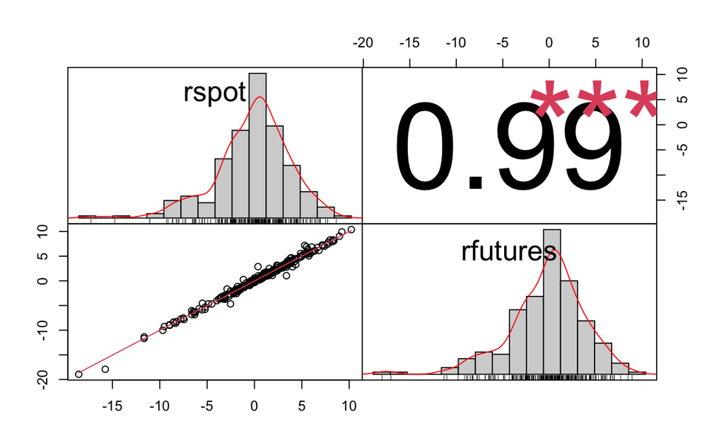

```r
hedge_clean %>% dplyr::select(rspot, rfutures) %>% chart.Correlation()
```

É possível observar a assimetria negativa nas duas séries de retornos pelo histograma das distribuições das duas séries. Além disso, o gráfico de dispersão indica uma forte relação linear entre as duas séries, o que é esperado pelo fato de serem retornos nos mercados à vista e de futuros para o índice S&P (500).

## 5. Estimação do Modelo de Regressão Linear Simples

Estimação dos parâmetros do modelo com a função `lm()`. Como estamos interessados na estimação da razão ótima de hedge, utilizamos os retornos como variáveis $y$ e $x$ no modelo de regressão linear simples:

```r
reg_retornos <- lm(rspot ~ rfutures, data = hedge_clean)
summary(reg_retornos)
```

```
Call:
lm(formula = rspot ~ rfutures, data = hedge_clean)

Residuals:
     Min       1Q   Median       3Q      Max
-2.45284 -0.16401  0.00236  0.23692  2.33789

Coefficients:
            Estimate Std. Error t value Pr(>|t|)
(Intercept) 0.013077   0.029473   0.444    0.658
rfutures    0.975077   0.006654 146.543   <2e-16 ***
---
Signif. codes:  0 ‘***’ 0.001 ‘**’ 0.01 ‘*’ 0.05 ‘.’ 0.1 ‘ ’ 1

Residual standard error: 0.4602 on 244 degrees of freedom
Multiple R-squared:  0.9888,    Adjusted R-squared:  0.9887
F-statistic: 2.147e+04 on 1 and 244 DF,  p-value: < 2.2e-16
```

```r
names(reg_retornos)
```

```
 [1] "coefficients"  "residuals"     "effects"       "rank"
 [5] "fitted.values" "assign"        "qr"            "df.residual"
 [9] "xlevels"       "call"          "terms"         "model"
```

## 6. Diagnóstico do Modelo

### 6.1 Verificando a adequação do modelo linear e de endogeneidade por omissão de variáveis

Podemos Verificar a adequação do modelo linear pelo teste RESET:

```r
## Teste RESET
lmtest::resettest(reg_retornos, type = "regressor")
```

```
    RESET test

data:  reg_retornos
RESET = 2.3201, df1 = 2, df2 = 242, p-value = 0.1004
```

Como o valor-p = 0.1004, os dados da amostra fornecem evidência de que o modelo linear é adequado para modelar a relação entre os retornos, nos mercado à vista e futuro, do índice S&P (500).

Conclusão alternativa, os dados fornecem evidência para não rejeitarmos a hipótese nula de que o modelo linear é adequado.

Além disso, o valor-p = 0.1004 do teste RESET, fornece evidências de que não há forte evidência de endogeneidade por omissão de variáveis.

Observando o gráfico dos resíduos contra os valores ajustados, vê-se que os resíduos flutuam de forma relativamente satisfatória em torno de zero, o que também fornece evidências da adequação do modelo linear.

Além disso, não há evidências de um padrão sistemático consistente que não tenha sido capturado pelo modelo:

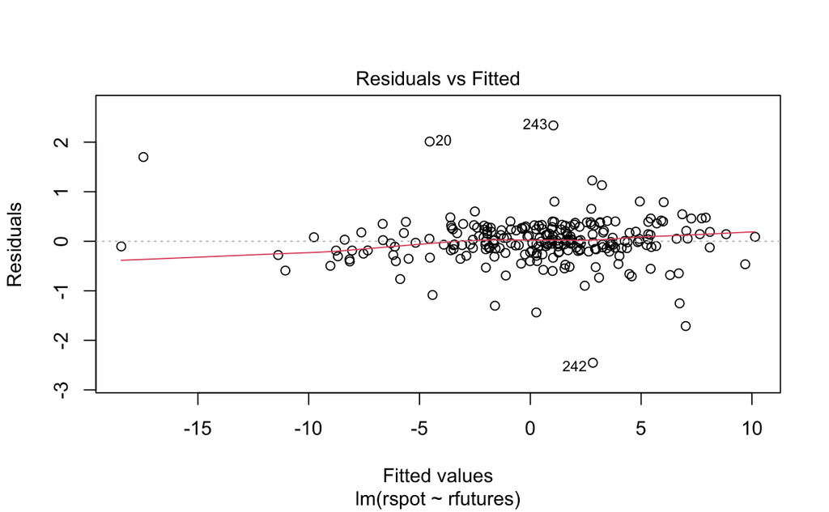

```r
plot(reg_retornos, 1)
```

### 6.2 Verificando a normalidade aproximada dos resíduos.

Pela versão robusta do teste de Jarque-Bera:

```r
DescTools::JarqueBeraTest(reg_retornos$residuals, robust = TRUE)
```

```
    Robust Jarque Bera Test

data:  reg_retornos$residuals
X-squared = 2159.3, df = 2, p-value < 2.2e-16
```

Como valor-p do teste de Jarque-Bera é muito pequeno, os dados fornecem evidência para rejeitarmos a hipótese nula de que os resíduos tem distribuição aproximadamente normal.

Pelo gráfico quantil-quantil dos resíduos, verifica-se que os resíduos do modelo possuem caudas pesasdas, isto é, há mais outliers do que espera-se em uma distribuição normal, o que constitui uma característica empírica amplamente observada em retornos de ações.

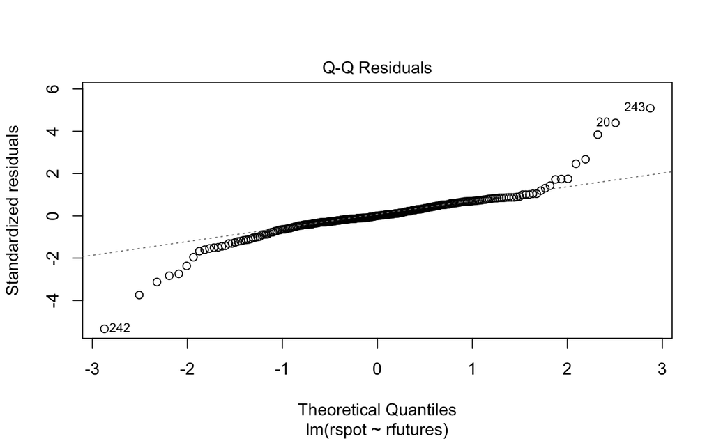

```r
plot(reg_retornos, 2)
```

Pelo gráfico quantil-quantil dos resíduos studentizados, observamos alguns resíduos fora dos limites de confiança, o que novamente fornece forte evidência de que os resíduos não seguem uma distribuição aproximadamente normal.

```
[1] 242 243
```

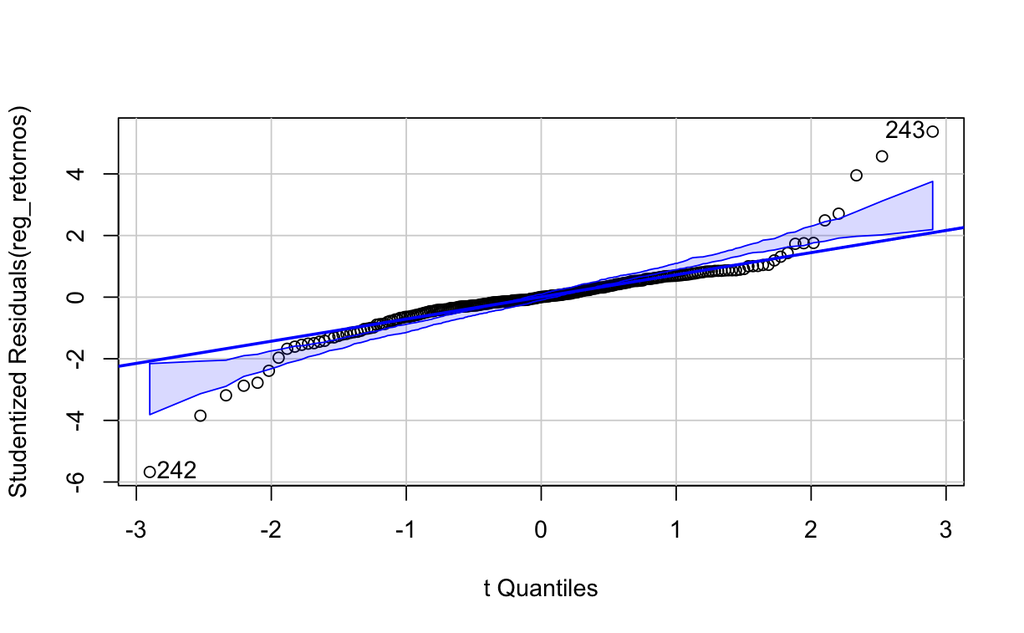

```r
car::qqPlot(reg_retornos, envelope = 0.95)
```

#### 6.2.1 Estratégias para a não-normalidade dos resíduos

A hipótese de que os resíduos tenham uma distribuição aproximadamente normal desempenha apenas um papel menor na análise de regressão linear. Ela é necessária principalmente para inferência em amostras pequenas e, nestes casos, a técnica bootstrap pode ser usada para inferência.

Para casos mais relevantes de não normalidade dos resíduos, uma estratégia possível é a utilização de métodos não-paramétricos ou regressão robusta.

A função `rlm()` do pacote `MASS` estima um modelo linear por regressão robusta usando um estimador M.

```r
library(MASS)
reg_rob <- rlm(rspot ~ rfutures, data = hedge_clean)
summary(reg_rob)
```

```
Call: rlm(formula = rspot ~ rfutures, data = hedge_clean)
Residuals:
     Min       1Q   Median       3Q      Max
-2.49320 -0.18890 -0.02771  0.23011  2.31762

Coefficients:
            Value    Std. Error t value
(Intercept)   0.0218   0.0194     1.1212
rfutures      0.9861   0.0044   224.6494

Residual standard error: 0.3072 on 244 degrees of freedom
```

### 6.3 Verificando a homogeneidade da variância do resíduo:

Podemos verificar a homocedasticidade (ou homogeneidade) da variância dos resíduos pelo Teste de Breusch-Pagan.

```r
lmtest::bptest(reg_retornos)
```

```
    studentized Breusch-Pagan test

data:  reg_retornos
BP = 0.070052, df = 1, p-value = 0.7913
```

Visto que o valor-p do teste foi 0.7913, os dados fornecem evidências para não rejeitar-se a hipótese nula de que a variância dos resíduos é homogênea ou homocedástica.

#### 6.3.1 Estratégia para Heterocedasticidade: Erros-Padrão Robustos

Caso a variância dos resíduos apresente heterocedasticidade (variância não homogênea), a estimativa da matriz de variância-covariância é viesada, pois a estimativa de $\hat{\sigma}^2$ é viesada.

Isso significa que os procedimentos de inferência padrão, como testes t ou testes F e intervalos de confiança não são confiáveis. A estratégia, amplamente utilizada em econometria, é a estimativa de erros-padrão robustos à heterocedasticidade.

Há diversas correções propostas para a estimativa da matriz de variância-covariância quando é identificada a presença de heterocedasticidade. Estas metodologias foram implementadas comas funções `coeftest()` e `vcovHC()` do pacote `sandwich`.

O método escolhido é definido pelo argumento `type` da função `vcovHC()`, o padrão é a utilização do método `HC3` proposto por MacKinnon & White (1985).

```r
library(sandwich)

## Aplicando a correção
ep_robustos <- coeftest(reg_retornos, vcov = vcovHC(reg_retornos, type = "HC3"))
```

### 6.4 Verificando obsservacoes influentes e outliers

A função interna `influence.measures()` calcula diversas medidas para a identificação de observações influentes. As observações avaliadas como influentes em relação a qualquer uma dessas medidas são marcados com um asterisco.:

```r
obs_influentes <- influence.measures(reg_retornos)
summary(obs_influentes)
```

```
Potentially influential observations of
     lm(formula = rspot ~ rfutures, data = hedge_clean) :

    dfb.1_ dfb.rftr dffit   cov.r   cook.d hat
2    0.15   0.10     0.19    0.96_*  0.02   0.01
10  -0.20   0.01    -0.20    0.93_*  0.02   0.00
11   0.36  -1.09_*   1.12_*  0.96_*  0.59   0.07_*
15  -0.15  -0.26    -0.32_*  0.96_*  0.05   0.01
16   0.16   0.10     0.20    0.96_*  0.02   0.01
20   0.32  -0.34     0.45_*  0.86_*  0.09   0.01
21  -0.21  -0.38    -0.45_*  0.91_*  0.10   0.01
24  -0.19   0.09    -0.20    0.95_*  0.02   0.00
36  -0.17   0.17    -0.23    0.97_*  0.03   0.01
38   0.01  -0.01     0.01    1.03_*  0.00   0.02
41   0.01  -0.03     0.03    1.04_*  0.00   0.03_*
58  -0.03   0.05    -0.06    1.03_*  0.00   0.02
60  -0.05   0.11    -0.12    1.04_*  0.01   0.03_*
129 -0.05   0.09    -0.10    1.03_*  0.01   0.02
133 -0.02   0.07    -0.07    1.10_*  0.00   0.08_*
136 -0.03   0.06    -0.06    1.03_*  0.00   0.02
137 -0.11   0.23    -0.24    1.03_*  0.03   0.03_*
139  0.02   0.04     0.04    1.03_*  0.00   0.02
168  0.03  -0.05     0.05    1.03_*  0.00   0.02
169  0.01   0.03     0.03    1.03_*  0.00   0.02_*
217 -0.01  -0.03    -0.04    1.03_*  0.00   0.02
242 -0.34  -0.20    -0.42_*  0.79_*  0.08   0.01
243  0.34   0.05     0.35_*  0.81_*  0.05   0.00
```

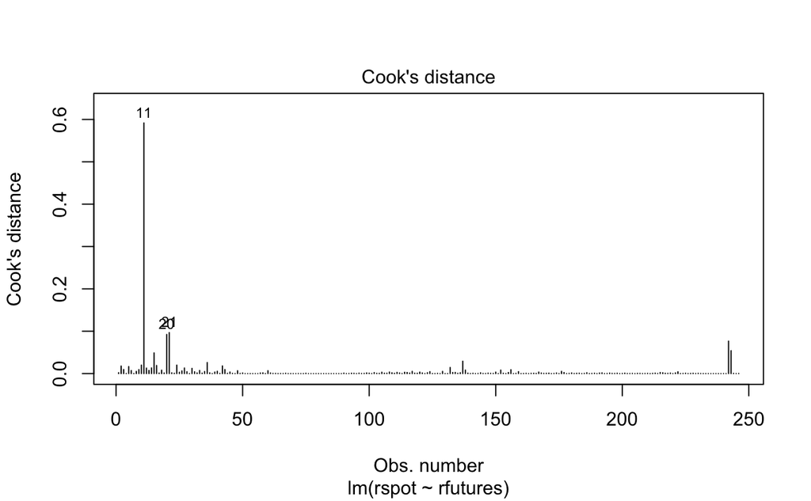

```r
plot(reg_retornos, 4)
```

### 6.5 Outros Procedimentos de Inferência Estatística

Como estamos interessados em obter uma estimativa da razão ótima de hedge, é relevante testarmos se $H_0: \beta_1 = 1$.

```r
car::linearHypothesis(reg_retornos, c("rfutures = 1"))
```

```
Linear hypothesis test

Hypothesis:
rfutures = 1

Model 1: restricted model
Model 2: rspot ~ rfutures

  Res.Df    RSS Df Sum of Sq     F    Pr(>F)
1    245 54.656
2    244 51.684  1    2.9718 14.03 0.0002246 ***
---
Signif. codes:  0 ‘***’ 0.001 ‘**’ 0.01 ‘*’ 0.05 ‘.’ 0.1 ‘ ’ 1
```

Considerando que o valor-p do teste F é 0.0002246, os dados fornecem evidências para rejeitarmos a hipótese nula de que $\beta_1 = 1$.

```r
car::linearHypothesis(reg_retornos, c("rfutures = 1"),
                      vcov = hccm(reg_retornos, type = "hc3"))
```

```
Linear hypothesis test

Hypothesis:
rfutures = 1

Model 1: restricted model
Model 2: rspot ~ rfutures

Note: Coefficient covariance matrix supplied.

  Res.Df Df      F   Pr(>F)
1    245
2    244  1 7.0976 0.008233 **
---
Signif. codes:  0 ‘***’ 0.001 ‘**’ 0.01 ‘*’ 0.05 ‘.’ 0.1 ‘ ’ 1
```

## 7. Comunicação dos Resultados

`modelsummary` é um pacote R que crie tabelas personalizáveis para resumir a estimação de diversos modelos estatísticos. Além disso, pode criar gráficos de coeficientes, tabelas cruzadas de vários níveis, resumos de conjuntos de dados e matrizes de correlação.

Este pacote suporta dezenas de modelos estatísticos e pode produzir tabelas em HTML, LaTeX, Word, Markdown, PDF, PowerPoint, Excel, RTF, JPG ou PNG. A s tabelas podem ser facilmente incorporadas em documentos dinâmicos ‘Rmarkdown’ ou ‘knitr’.

A tabelas a seguir reporta os resultados da estimação da razão ótima de hedge usando o modelo de regressão linear:

```r
msummary(reg_retornos,
         statistic = c("conf.int"),
         vcov = 'robust',
         stars = c('*' = .1, '**' = .05, '***' = .01))
```

|  | (1) |
| --- | --- |
| (Intercept) | 0.013 |
|  | [−0.046, 0.072] |
| rfutures | 0.975*** |
|  | [0.957, 0.994] |
| Num.Obs. | 246 |
| R2 | 0.989 |
| R2 Adj. | 0.989 |
| AIC | 320.3 |
| BIC | 330.8 |
| Log.Lik. | −157.157 |
| F | 10864.034 |
| RMSE | 0.46 |
| Std.Errors | HC3 |

* p < 0.1, ** p < 0.05, *** p < 0.01